# Data Science

## Clustering

Alessandro D. Gagliardi

## Agenda:

1. Midterm & Project Discussion
2. Prework
3. Lecture
4. Lab

# Midterm Postmortem

# Projects

### Next Deadline:

## 6/4 - Incorporate feedback (resolve issues) and have at least one working ML model checked into your repo

# Clustering

### Pre-Work

- 12 minutes - Independent Research
- 6 minutes - Small Group Discussion
- ~5 minutes - Class Discussion

# On Your Own

Say you had access to all of Amazon's or Netflix's customer behavior information and you were tasked to identify types or classes of customers based upon their behavior and/or demographic information. Spend 12 minutes on your own researching how you might do this. You may use the Internet or your own imagination to solve this problem.

# In Groups of ~4

Spend 6 minutes discussing your solution with the person next to you. Spend 1-2 minutes each explaining your solution and 1-2 minutes comparing your solutions. One delegate from each group will report findings.

# Group Report

## Clustering

1. k-Nearest Neighbors Classification
2. Hierarchical Clustering
3. k-Means Clustering

# k-Nearest Neighbors

[figure not shown]

## Suppose we want to predict the color of the gray dot.

- Pick value for k
- Find colors of k nearest neighbors
- Assign most common color to gray dot

[figure not shown]

# Distance

- How we measure distance is very important in kNN.
- By default, we use Euclidean distance: $d = \sqrt{\sum(x_i - p_i)^2}$
- Any problems with this?

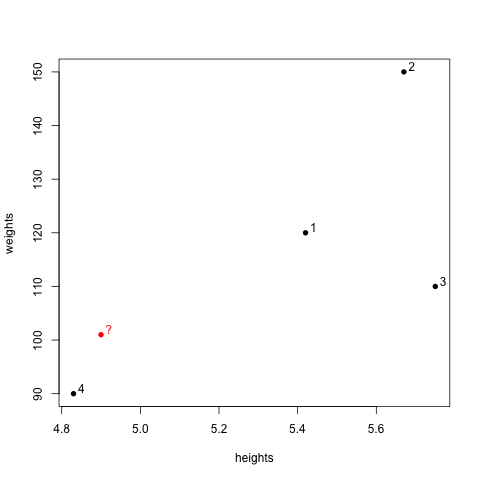

```python
%%R
d <- data.frame(heights=c(5.42, 5.67, 5.75, 4.83), weights=c(120, 150, 110, 90))
plot(d, pch=16)
text(d$heights + .02, y = d$weights + 1, labels = seq(4))
points(x=c(4.9), y=c(101), col=2, pch=16)
text(4.92, y = 102, labels = "?", col=2)
```

Which black dot is closest to the red one?

```python
%%R
sqrt((4.9 - d$heights)^2 + (101 - d$weights)^2)
```

```
[1] 19.00711 49.00605  9.04005 11.00022
```

# Moral:

### Don't forget to scale!

$$ x_{scaled} = \frac{x - \bar{x}}{\sigma_x} $$

```python
%%R
d2 <- data.frame(scale(d))
sqrt((((4.9 - mean(d$heights)) / sd(d$heights)) - d2$heights)^2 +
     (((101 - mean(d$weights)) / sd(d$weights)) - d2$weights)^2)
```

```
[1] 1.4625924 2.6954840 2.0741460 0.4710603
```

...or use a different distance metric (depending on the data)

### In general, a distance measure must satisfy certain general conditions:

$ d(x,y) \ge 0$  
$ d(x,y) \Longleftrightarrow x = y $  
$ d(x,y) = d(y,x) \qquad $ (symmetry)  
$ d(x,y) + d(y,z) \ge d(x,z) \quad $ (triangle inequality)

There are a number of different similarity measures to choose from, and in general the right choice depends on the problem.

For data that takes values in $\mathbb{R}^n$, the typical choice is the Euclidean distance: $d(x,y) = \sqrt{\sum(x_i - y_i)^2}$

We can express different semantics about our data through the choice of metric.

Ex: One popular metric for text mining problems (or any problem with *sparse binary* data) is the **Jaccard coefficient**, $$ J(A,B) = \frac{|A \cap B |}{| A \cup B|} $$

Applying this metric to a problem expresses the sparse nature of the data, and makes a variety of text mining techniques accessible.

### KNN is an *non-parametric lazy* learning algorithm.

#### **non-parametric**:

does not make any assumptions on the underlying data distribution.

*N.B. The classification is non-parametric, but the distance measure is not*

#### **lazy**:

does not use the training data points to do any generalization

### Parametric vs. Non-parametric

Say you have the following dataset:

```python
x = np.array([0.001, 23.4, 17.3, 26.8, 32.8, 31.3, 34.5, 7352.3])
```

Because of one outlier (7352.3), standard metrics like `mean` and `sd` become meaningless.

```python
x.mean()
```

```
939.80012499999998
```

```python
x.std()
```

```
2423.7195578387591
```

### Non-parametric

ignore the actual value and compare only relative position, i.e. the rank.

Imagine the following are the distances to eight points:

```
0.001, 23.4, 17.3, 26.8, 32.8, 31.3, 34.5, 7352.3
```

is treated the same as

```
1, 3, 2, 4, 6, 5, 7, 8
```

## What if you don't know your class labels in advance?

[figure not shown]

Q: What is a cluster?

A: A group of **similar** data points.

The concept of similarity is central to the definition of a cluster, and therefore to cluster analysis.

In general, greater similarity between points leads to better clustering.

Q: What is the purpose of cluster analysis?

A: To enhance our understanding of a dataset by dividing the data into groups.

Clustering provides a layer of *abstraction* from individual data points.

The goal is to extract and enhance the natural structure of the data (not to impose arbitrary structure!)

Q: How do you solve a clustering problem?

A: Think of a cluster as a “potential class”; then the solution to a clustering problem is to programatically determine these classes.

The real purpose of clustering is data exploration, so a solution is anything that contributes to your understanding.

# Hierarchical Clustering

## Single Linkage Hierarchical Clustering

1) Say "Every point is its own cluster"

2) Find “most similar” pair of clusters

3) Merge it into a parent cluster

4) Repeat

Raw data:

[figure not shown]

Hierarchical Representation:

[figure not shown]

### Pros:

- Few assumptions (any distance measure will do, no assumptions required about the number of clusters)
- Structure of dendogram reveals much about the data

### Cons:

- Very slow: $O(n^3)$ (especially on big data)

# K-Means Clustering

Q: What is k-means clustering?

A: A **greedy** learner that **partitions** a data set into k clusters.

greedy – captures local structure (depends on initial conditions)

partition – performs complete clustering (each point belongs to exactly one cluster)

Q: How are these partitions determined?

A: Each point is assigned to the cluster with the nearest **centroid**.

centroid – the mean of the data points in a cluster  
$\rightarrow$ requires continuous (vector-like) features  
$\rightarrow$ highlights iterative nature of algorithm

## Centroids & Partitions

Q: What do these partitions look like?

[figure not shown]

## Scale Dependance

One important point to keep in mind is that (like kNN) partitions are not scale-invariant!

This means that the same data can yield very different clustering results depending on the scale and the units used.

Therefore it’s important to think about your data representation before applying a clustering algorithm.

[figure not shown]

## The Basic K-means Algorithm

1. Choose $k$ initial centroids (note that $k$ is an input)
2. For each point:
   - find distance to each centroid
   - assign point to nearest centroid
3. Recalculate centroid positions
4. Repeat steps 2-3 until stopping criteria met

[figure not shown]

## Strengths & Weaknesses

K-means is algorithmically pretty efficient (time & space complexity is linear in number of records).

It has a hard time dealing with non-convex clusters, or data with widely varying shapes and densities.

Difficulties can sometimes be overcome by increasing the value of $k$ and combining subclusters in a post-processing step.

## Step 1 - Choosing Initial Centroids

Q: How do you choose the initial centroid positions?

A: There are several options:

- randomly (but may yield divergent behavior)
- perform alternative clustering task, use resulting centroids as initial k-means centroids
- start with global centroid, choose point at max distance, repeat (but might select outlier)

## Step 2 - Similarity Measures

Q: How do you determine which centroid is the nearest?

The “nearness” criterion is determined by the similarity/distance measure we discussed earlier.

This measure makes quantitative inference possible.

The matrix whose entries $D_{ij}$ contain the values $d(x, y)$ for all $x$ and $y$ is called the distance matrix.

The distance matrix contains *all of the information* we know about the dataset.

For this reason, it’s really the choice of metric that determines the definition of a cluster.

## Step 3 - Objective Function

Q: How do we recompute the positions of the centroids at each iteration of the algorithm?

A: By optimizing an **objective function** that tells us how “good” the clustering is.

The iterative part of the algorithm (recomputing centroids and reassigning points to clusters) explicitly tries to minimize this objective function.

Ex: Using the Euclidean distance measure, one typical objective function is the **sum of squared errors** from each point $x$ to its centroid $c_i$:

$$ SSE = \sum\limits_{i=1}^K\sum\limits_{x \in C_i}d(x_i,c_i)^2$$

Given two clusterings, we will prefer the one with the lower SSE since this means the centroids have converged to better locations (a better local optimum).

## Step 4 - Convergence

We iterate until some stopping criteria are met; in general, suitable convergence is achieved in a small number of steps.

Stopping criteria can be based on the centroids (e.g. if positions change by no more than $\epsilon$) or on the points (e.g. if no more than $x\%$ change clusters between iterations).

Recall that, in general, different runs of the algorithm will converge to different local optima (centroid configurations).

# Questions?

# LAB

In the `DAT6` folder, from the command line:

```bash
git commit -am ...
git checkout gh-pages
git pull
git checkout personal
git merge gh-pages
ipython notebook
```

Then open `DS_Lab12-Clustering`